# Approach 2 under multipath — analysis (v11)

Analysis only: `approaches.py` is not changed. Per dot of the real MPI corners (`MPI_sweep_real_v11.ipynb`, both folders) the Approach-2 inputs are compared with the **scene GT** (10x10 triangulation, SL only):

1. **Error budget** — SL error, ToF error (multipath: ToF ≥ GT) and the fusion weight w_ToF = σ_SL² / (σ_SL² + σ_ToF²), over the distance to the fold.
2. **Variants**, computed offline from the same per-dot inputs:
   - `A2` — as implemented (precision-weighted mean, no fusion beyond `FUSION_MAX_SIGMA` = 20σ)
   - `SL` / `ToF` — the inputs alone
   - `b) one-sided` — multipath can only lengthen the ToF: if z_ToF − z_SL > k·σ, the ToF is dropped and the SL depth is used; otherwise A2
   - `c) σ_MPI` — σ_ToF² + max(0, z_ToF − z_SL)²: the ToF loses weight as far as it lies behind the SL
   - `a) peak` — SL peak picked without the ToF (most prominent blob-backed peak on the trail, as in the scene GT), then A2 fusion — shows whether the peak choice in front of the ToF costs anything
3. Conclusion: which change to Approach 2 is worth it, and how much.

Errors are axial depth errors along the pixel ray, e = z − z_GT (+ = behind the GT, the multipath direction), on the dots inside the region of interest of the sweep notebook.

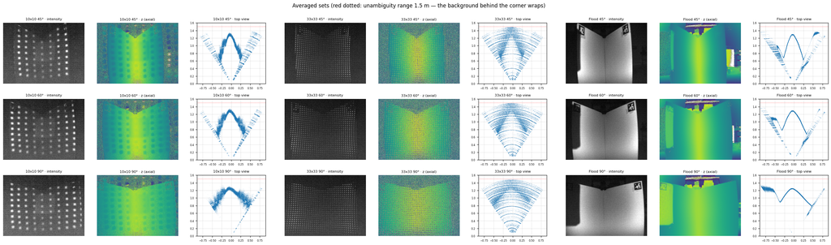

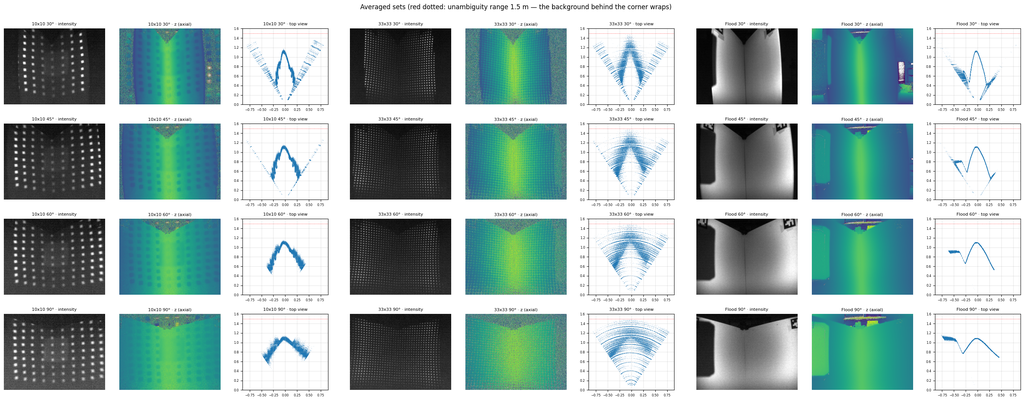

```
1.3m: angles (45, 60, 90), scene GT d = 45°: 1.303 m, 60°: 1.270 m, 90°: 1.274 m
1m: angles (30, 45, 60, 90), scene GT d = 30°: 1.083 m, 45°: 1.100 m, 60°: 1.093 m, 90°: 1.082 m
```

```python
import contextlib, io, json, os, sys
from pathlib import Path
import numpy as np
import matplotlib.pyplot as plt

SWEEP_NB = Path("MPI_sweep_real_v11.ipynb")
ROOTS = {"1.3m": "/home/julian/Documents/Calibrations/MPI_Messung_07.10",
         "1m":   "/home/julian/Documents/Calibrations/MPI_Messung_07.10/MPI_1m_WW"}
K_ONESIDED = 3.0          # b) ToF dropped if it lies more than K·σ_comb behind the SL
FOLD_BINS = [0.0, 0.05, 0.15, 1.0]   # [m] lateral distance to the fold
# The variants below start from the original fusion; approaches.FUSION_MPI_SIGMA (= variant c, now
# the default) is switched off here so that "A2" is the unchanged Approach 2 and c) is not applied twice.
import approaches
approaches.FUSION_MPI_SIGMA = False


from dot_calibration import DotCalibration
_LOAD_TOF_PCD = DotCalibration.load_tof_pcd   # the sweep cells wrap it (SOR, LPC) — unwrap per folder


def sweep_namespace(root):
    # Runs the setup + scene-GT cells of the sweep notebook (everything up to the region of interest);
    # all heavy steps come from its caches. Returns its global namespace.
    os.environ["MPI_MEAS_ROOT"] = root
    DotCalibration.load_tof_pcd = _LOAD_TOF_PCD
    nb = json.loads(SWEEP_NB.read_text())
    ns = {"__name__": "__sweep__"}
    for c in nb["cells"]:
        if c["cell_type"] != "code":
            continue
        src = "".join(c["source"])
        if src.lstrip().startswith(("plot_topview()", "import pickle")):
            continue
        with contextlib.redirect_stdout(io.StringIO()):
            exec(compile(src, "sweep", "exec"), ns)
        if "SWEEP" in ns and "EVAL" in ns and len(ns["EVAL"]) == len(ns["ANGLES"]):
            break
    return ns


NS = {tag: sweep_namespace(root) for tag, root in ROOTS.items()}
for tag, ns in NS.items():
    print(f"{tag}: angles {ns['ANGLES']}, scene GT d = "
          + ", ".join(f"{a}°: {ns['SCENE'][a]['dist']:.3f} m" for a in ns["ANGLES"]))
```

## Per-dot inputs of Approach 2

```python
def z_gt_axial(ns, angle, P):
    # Axial GT depth along the ray of each point P (camera frame) = where the ray hits the scene corner.
    walls = ns["SCENE"][angle]["walls"]
    t = ns["ray_range_to_corner"](P, walls)
    return t * P[:, 2] / np.linalg.norm(P, axis=1)


def prominent_peak_z(ns, setup, tr):
    # Variant a): SL depth of the most prominent blob-backed peak (no ToF), as in the scene GT.
    ap, dotCal = ns["approaches"], ns["dotCal"]
    ab = ap.saturation_correct(ap.sample_trail_brightness(setup["sl_gray"], tr), setup["sat_level"])
    if not np.any(np.isfinite(ab)) or setup["blob_tree"] is None:
        return np.nan
    sig_s, base, pk = ap.trail_peaks(np.where(np.isfinite(ab), ab, 0.0))
    if len(pk):
        d_blob, _ = setup["blob_tree"].query(np.c_[tr["u"][pk], tr["v"][pk]])
        pk = pk[d_blob <= ap.BLOB_RADIUS]
    if not len(pk):
        return np.nan
    k0 = int(pk[np.argmax((sig_s - base)[pk])])
    k_sub, _ = ap.refine_on_trail(dotCal, setup["sl_gray"], tr, ap.quad_subpixel(sig_s, k0, baseline=base),
                                  k_anchor=k0)
    return 1.0 / float(np.interp(k_sub, np.arange(len(tr["w"]), dtype=float), tr["w"]))


def dot_table(ns, pat, angle):
    ap = ns["approaches"]
    s, cal = ns["SETS"][(pat, angle)], ns["CALS"][pat]
    with contextlib.redirect_stdout(io.StringIO()):
        setup = ap.common_setup(ns["dotCal"], cal, str(s["exr"]), str(s["pcd"]))
        res = ap.run_approach_2(ns["dotCal"], cal, setup, make_plots=False)["results"]
    _, sigma_sl_fn, sigma_tof_fn = ap.sigma_models(cal)
    rx, ry = ns["RAYS"][pat]
    from scipy.ndimage import map_coordinates
    rows = []
    for r in res:
        if not (np.isfinite(r["u_sub"]) and np.isfinite(r["z_sl"]) and np.isfinite(r["z_tof"])):
            continue
        if ap.ab_gated(r, sigma_tof_fn, ap.FUSION_MAX_SIGMA):
            continue
        u, v = r["u_sub"], r["v_sub"]
        if not ns["ROI_MASK"][angle][int(round(v)), int(round(u))]:
            continue
        ray = np.array([map_coordinates(rx, [[v], [u]], order=1)[0], map_coordinates(ry, [[v], [u]], order=1)[0], 1.0])
        zg = z_gt_axial(ns, angle, ray[None, :])[0]
        x_fold = abs(ns["SCENE"][angle]["to_corner"]((ray * zg)[None, :])[0, 0])
        tr = setup["trails"][r["i"]]
        rows.append(dict(z_sl=r["z_sl"], z_tof=r["z_tof"], z_fus=r["z_fus"], conflict=r["conflict"],
                         s_sl=sigma_sl_fn(r["z_sl"], r.get("gain")), s_tof=sigma_tof_fn(r["z_tof"]),
                         z_gt=zg, x_fold=x_fold, z_sl_prom=prominent_peak_z(ns, setup, tr)))
    return {k: np.array([row[k] for row in rows], float) for k in rows[0]} if rows else None


D = {}
for tag, ns in NS.items():
    for angle in ns["ANGLES"]:
        for pat in ns["PATTERNS"]:
            D[(tag, angle, pat)] = dot_table(ns, pat, angle)
            t = D[(tag, angle, pat)]
            print(f"{tag} {angle:>2d}° {pat}: {0 if t is None else len(t['z_gt'])} dots in the ROI with SL + ToF")
```

```
1.3m 45° 10x10: 19 dots in the ROI with SL + ToF
```

```
1.3m 45° 33x33: 394 dots in the ROI with SL + ToF
```

```
1.3m 60° 10x10: 33 dots in the ROI with SL + ToF
```

```
1.3m 60° 33x33: 543 dots in the ROI with SL + ToF
```

```
1.3m 90° 10x10: 31 dots in the ROI with SL + ToF
```

```
1.3m 90° 33x33: 630 dots in the ROI with SL + ToF
```

```
1m 30° 10x10: 19 dots in the ROI with SL + ToF
```

```
1m 30° 33x33: 408 dots in the ROI with SL + ToF
```

```
1m 45° 10x10: 33 dots in the ROI with SL + ToF
```

```
1m 45° 33x33: 601 dots in the ROI with SL + ToF
```

```
1m 60° 10x10: 39 dots in the ROI with SL + ToF
```

```
1m 60° 33x33: 696 dots in the ROI with SL + ToF
```

```
1m 90° 10x10: 44 dots in the ROI with SL + ToF
```

```
1m 90° 33x33: 732 dots in the ROI with SL + ToF
```

## 1. Error budget

e_SL = z_SL − z_GT, e_ToF = z_ToF − z_GT. Without a conflict, A2 = w_ToF·z_ToF + (1 − w_ToF)·z_SL, so e_A2 = w_ToF·e_ToF + (1 − w_ToF)·e_SL. Medians per pattern over all angles, split by the lateral distance to the fold.

```python
def budget(t):
    e_sl, e_tof = t["z_sl"] - t["z_gt"], t["z_tof"] - t["z_gt"]
    w_tof = t["s_sl"] ** 2 / (t["s_sl"] ** 2 + t["s_tof"] ** 2)
    return e_sl, e_tof, w_tof


print(f"{'':16s}{'fold dist':>11s}{'n':>6s}{'e_SL':>9s}{'e_ToF':>9s}{'ToF>GT':>8s}{'w_ToF':>8s}"
      f"{'σ_SL':>7s}{'σ_ToF':>7s}{'w·e_ToF':>9s}{'(1-w)e_SL':>11s}{'e_A2':>8s}   [mm, medians]")
for tag in NS:
    for pat in ("10x10", "33x33"):
        ts = [D[k] for k in D if k[0] == tag and k[2] == pat and D[k] is not None]
        t = {k: np.concatenate([x[k] for x in ts]) for k in ts[0]}
        e_sl, e_tof, w = budget(t)
        for lo, hi in zip(FOLD_BINS[:-1], FOLD_BINS[1:]):
            m = (t["x_fold"] >= lo) & (t["x_fold"] < hi)
            if m.sum() < 3:
                continue
            ea2 = t["z_fus"][m] - t["z_gt"][m]
            print(f"{tag:5s} {pat:9s} {lo * 100:3.0f}–{hi * 100:3.0f} cm{m.sum():6d}"
                  f"{np.median(e_sl[m]) * 1e3:9.1f}{np.median(e_tof[m]) * 1e3:9.1f}{np.mean(e_tof[m] > 0):8.0%}"
                  f"{np.median(w[m]):8.2f}{np.median(t['s_sl'][m]) * 1e3:7.1f}{np.median(t['s_tof'][m]) * 1e3:7.1f}"
                  f"{np.median(w[m] * e_tof[m]) * 1e3:9.1f}{np.median((1 - w[m]) * e_sl[m]) * 1e3:11.1f}"
                  f"{np.nanmedian(ea2) * 1e3:8.1f}")
```

```
                  fold dist     n     e_SL    e_ToF  ToF>GT   w_ToF   σ_SL  σ_ToF  w·e_ToF  (1-w)e_SL    e_A2   [mm, medians]
1.3m  10x10       0–  5 cm     8    -38.6      9.7     75%    0.99   27.1    2.4      9.6       -0.4     9.5
1.3m  10x10       5– 15 cm    29    -19.3     15.3     76%    0.99   19.8    2.3     15.0       -0.2    15.4
1.3m  10x10      15–100 cm    46     -1.9      5.5     72%    0.98   12.7    2.3      5.3       -0.0     4.9
1.3m  33x33       0–  5 cm   145    -20.7     39.6     76%    0.95   12.0    2.8     38.0       -1.0    38.3
1.3m  33x33       5– 15 cm   418     -2.9     69.1     94%    0.93    9.5    2.6     63.7       -0.2    63.6
1.3m  33x33      15–100 cm  1004     -8.0     59.0    100%    0.86    6.6    2.6     50.3       -0.9    50.3
1m    10x10       0–  5 cm    20      5.9     10.8     75%    0.99   21.9    2.3     10.7        0.1    10.9
1m    10x10       5– 15 cm    49     -1.4     13.6     90%    0.97   12.1    2.3     13.2       -0.0    13.5
1m    10x10      15–100 cm    66      0.1      8.1     80%    0.97    9.2    1.8      7.7        0.0     7.9
1m    33x33       0–  5 cm   266    -11.5     73.3    100%    0.92    8.6    2.5     67.1       -0.9    66.2
1m    33x33       5– 15 cm   970     -1.7     74.5    100%    0.82    5.6    2.6     57.3       -0.3    58.1
1m    33x33      15–100 cm  1201    -15.1     61.2    100%    0.75    4.5    2.7     44.3       -3.1    44.0
```

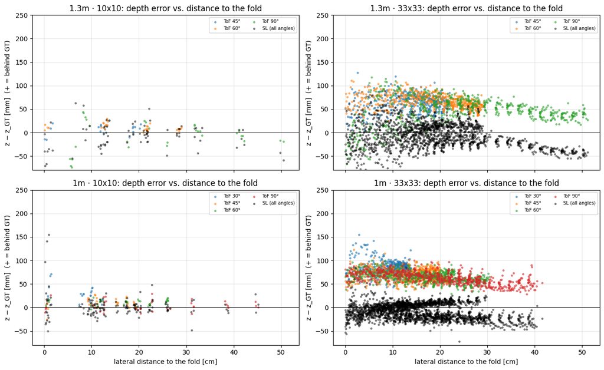

```python
fig, axs = plt.subplots(2, 2, figsize=(13, 8), sharex=True)
for i, tag in enumerate(NS):
    for j, pat in enumerate(("10x10", "33x33")):
        ax = axs[i, j]
        for (tg, angle, p), t in D.items():
            if tg != tag or p != pat or t is None:
                continue
            e_sl, e_tof, _ = budget(t)
            ax.scatter(t["x_fold"] * 100, e_tof * 1e3, s=6, alpha=0.5, label=f"ToF {angle}°")
        allt = [D[k] for k in D if k[0] == tag and k[2] == pat and D[k] is not None]
        x = np.concatenate([t["x_fold"] for t in allt]); es = np.concatenate([t["z_sl"] - t["z_gt"] for t in allt])
        ax.scatter(x * 100, es * 1e3, s=6, c="k", alpha=0.4, label="SL (all angles)")
        ax.axhline(0, color="k", lw=0.8)
        ax.set_ylim(-80, 250)
        ax.set_title(f"{tag} · {pat}: depth error vs. distance to the fold")
        ax.set_ylabel("z − z_GT [mm]  (+ = behind GT)")
        ax.grid(alpha=0.3)
        ax.legend(fontsize=7, ncol=2)
for ax in axs[-1]:
    ax.set_xlabel("lateral distance to the fold [cm]")
fig.tight_layout()
plt.show()
```

## 2. Variants (offline)

RMSE and median of e over the same dots per variant. `n` counts the dots a variant gives a depth to (A2 drops conflicts > 20σ).

```python
def variants(t):
    zs, zt, ss, st = t["z_sl"], t["z_tof"], t["s_sl"], t["s_tof"]
    sc = np.hypot(ss, st)
    fuse = lambda z1, s1, z2, s2: (z1 / s1 ** 2 + z2 / s2 ** 2) / (1 / s1 ** 2 + 1 / s2 ** 2)
    out = {"A2": t["z_fus"], "SL": zs, "ToF": zt}
    out["b) one-sided"] = np.where(zt - zs > K_ONESIDED * sc, zs, fuse(zs, ss, zt, st))
    st_mpi = np.hypot(st, np.maximum(0.0, zt - zs))
    out["c) σ_MPI"] = fuse(zs, ss, zt, st_mpi)
    zp = t["z_sl_prom"]
    out["a) peak"] = np.where(np.isfinite(zp), fuse(zp, ss, zt, st), np.nan)
    out["a)+b)"] = np.where(np.isfinite(zp), np.where(zt - zp > K_ONESIDED * sc, zp, fuse(zp, ss, zt, st)), np.nan)
    return out


NAMES = ["ToF", "SL", "A2", "b) one-sided", "c) σ_MPI", "a) peak", "a)+b)"]
SUMMARY = {}
for tag in NS:
    for pat in ("10x10", "33x33"):
        print(f"\n{tag} · {pat}   RMSE [mm] / median e [mm] / n")
        print(f"{'angle':>6s}" + "".join(f"{n:>18s}" for n in NAMES))
        for angle in NS[tag]["ANGLES"]:
            t = D.get((tag, angle, pat))
            if t is None:
                continue
            V = variants(t)
            cells_ = []
            for n in NAMES:
                e = V[n] - t["z_gt"]
                e = e[np.isfinite(e)]
                SUMMARY[(tag, pat, angle, n)] = (np.sqrt(np.mean(e ** 2)) if len(e) else np.nan,
                                                 np.median(e) if len(e) else np.nan, len(e))
                r, m, k = SUMMARY[(tag, pat, angle, n)]
                cells_.append(f"{r * 1e3:7.1f}/{m * 1e3:+6.1f}/{k:<3d}")
            print(f"{angle:5d}°" + "".join(f"{c:>18s}" for c in cells_))
        changed = np.concatenate([np.abs(D[k]["z_sl_prom"] - D[k]["z_sl"]) > 0.01
                                  for k in D if k[0] == tag and k[2] == pat and D[k] is not None])
        print(f"  a) peak differs from the A2 peak (> 10 mm) at {np.mean(changed):.1%} of the dots")
```

```
1.3m · 10x10   RMSE [mm] / median e [mm] / n
 angle               ToF                SL                A2      b) one-sided          c) σ_MPI           a) peak             a)+b)
   45°   13.4/ +10.6/19    28.0/  -6.3/19    13.2/ +10.8/19    14.4/  +8.4/19    22.0/  -9.3/19    13.2/ +10.8/19    14.4/  +8.4/19
   60°   13.4/  +8.5/33    36.1/  -2.6/33    13.0/  +8.3/33    33.0/  +8.1/33    34.3/  +2.6/33    13.0/  +8.3/33    33.0/  +8.1/33
   90°   34.5/  -6.0/31    48.7/ -10.4/31    34.6/  -5.6/31    42.3/  -6.8/31    43.8/  -9.0/31    34.6/  -5.6/31    42.3/  -6.8/31
  a) peak differs from the A2 peak (> 10 mm) at 0.0% of the dots

1.3m · 33x33   RMSE [mm] / median e [mm] / n
 angle               ToF                SL                A2      b) one-sided          c) σ_MPI           a) peak             a)+b)
   45°   65.0/ +63.9/394   44.4/  -6.6/394   55.9/ +53.4/393   44.5/  -6.2/394   44.3/  -5.9/394   53.1/ +50.7/394  182.3/  -9.2/394
   60°   68.3/ +65.3/543   21.7/  +0.5/543   60.6/ +56.8/543   23.2/  +0.8/543   22.1/  +1.3/543   56.8/ +53.7/543  178.1/  -9.2/543
   90°   54.4/ +48.5/630   34.5/ -13.6/630   49.9/ +41.7/630   36.1/ -12.4/630   34.5/ -12.0/630   52.0/ +41.6/630  251.6/ -15.0/630
  a) peak differs from the A2 peak (> 10 mm) at 10.1% of the dots

1m · 10x10   RMSE [mm] / median e [mm] / n
 angle               ToF                SL                A2      b) one-sided          c) σ_MPI           a) peak             a)+b)
   30°   35.0/ +28.7/19    13.4/  +2.7/19    34.5/ +27.5/19    29.4/ +12.9/19    14.0/  +6.0/19    34.5/ +27.5/19    29.4/ +12.9/19
   45°   14.3/ +10.0/33    27.7/  -0.5/33    13.7/  +9.6/33    13.6/  +8.8/33    11.3/  +2.4/33    13.7/  +9.6/33    13.6/  +8.8/33
   60°   12.2/ +12.3/39    29.0/  -0.8/39    11.8/ +12.5/39    12.0/ +11.9/39    11.3/  +1.3/39    11.8/ +12.5/39    12.0/ +11.9/39
   90°   11.1/  +1.2/44    22.4/  -1.9/44    11.0/  +1.3/44    10.8/  +0.7/44    12.4/  -2.0/44    11.0/  +1.3/44    10.8/  +0.7/44
  a) peak differs from the A2 peak (> 10 mm) at 0.0% of the dots

1m · 33x33   RMSE [mm] / median e [mm] / n
 angle               ToF                SL                A2      b) one-sided          c) σ_MPI           a) peak             a)+b)
   30°   85.3/ +83.9/408   16.2/  +2.1/408   64.5/ +58.1/308   16.2/  +2.1/408   16.3/  +2.4/408  279.1/ +56.1/408  274.8/  +3.3/408
   45°   70.2/ +69.1/601   17.6/ -12.9/601   49.6/ +47.5/559   17.6/ -12.9/601   17.4/ -12.4/601  312.1/ +47.9/601  310.8/  -9.7/601
   60°   65.6/ +64.8/696   18.5/ -12.6/696   50.9/ +50.9/682   18.3/ -12.6/696   18.2/ -12.2/696   59.9/ +50.6/696   68.9/ -12.6/696
   90°   64.4/ +63.1/732   18.6/  -5.2/732   54.7/ +54.1/731   18.6/  -5.2/732   18.5/  -4.5/732   55.5/ +52.1/732  113.2/  -8.1/732
  a) peak differs from the A2 peak (> 10 mm) at 3.9% of the dots
```

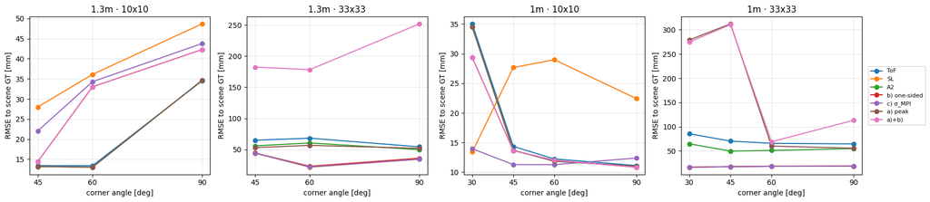

```python
fig, axs = plt.subplots(1, 4, figsize=(18, 4), sharey=False)
for ax, (tag, pat) in zip(axs, [(t, p) for t in NS for p in ("10x10", "33x33")]):
    for n in NAMES:
        ang = NS[tag]["ANGLES"]
        ax.plot(ang, [SUMMARY.get((tag, pat, a, n), (np.nan,))[0] * 1e3 for a in ang], "o-", label=n)
    ax.set_title(f"{tag} · {pat}")
    ax.set_xlabel("corner angle [deg]"); ax.set_ylabel("RMSE to scene GT [mm]")
    ax.set_xticks(NS[tag]["ANGLES"]); ax.grid(alpha=0.3)
axs[-1].legend(fontsize=8, loc="center left", bbox_to_anchor=(1.02, 0.5))
fig.tight_layout()
plt.show()
```

## 3. Conclusion

```python
def mean_rmse(pat, n):
    v = [SUMMARY[k][0] for k in SUMMARY if k[1] == pat and k[3] == n and np.isfinite(SUMMARY[k][0])]
    return np.mean(v) * 1e3 if v else np.nan


print(f"{'variant':16s}{'10x10':>10s}{'33x33':>10s}   mean RMSE over all corners [mm]")
for n in NAMES:
    print(f"{n:16s}{mean_rmse('10x10', n):10.1f}{mean_rmse('33x33', n):10.1f}")
```

```
variant              10x10     33x33   mean RMSE over all corners [mm]
ToF                   19.1      67.6
SL                    29.3      24.5
A2                    18.8      55.2
b) one-sided          22.2      24.9
c) σ_MPI              21.3      24.5
a) peak               18.8     124.1
a)+b)                 22.2     197.1
```